# Text_3_9~

1. Turn a stacked bar chart into a pie chart using coord_polar().

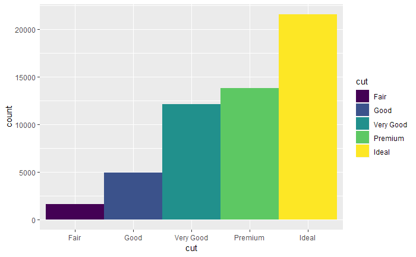

```r
bar_x <- ggplot(data = diamonds) + geom_bar(mapping = aes(x = cut, fill = cut),width = 1)
bar_x
```

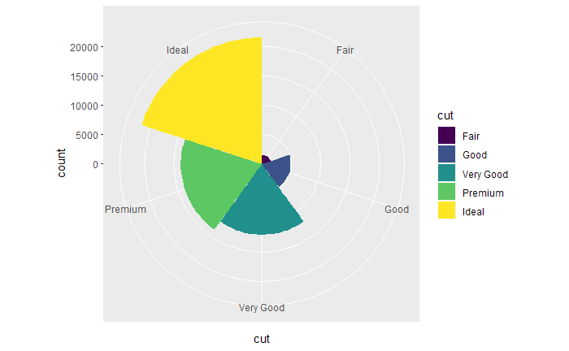

```r
bar_x + coord_polar()
```

- 위와 같이 coxcomb chart 처럼 된다. 우리가 원하는 정상적인 piechart를 만들기 위해서는 bar chart에서 x축을 하나로 모아야 한다. 따라서

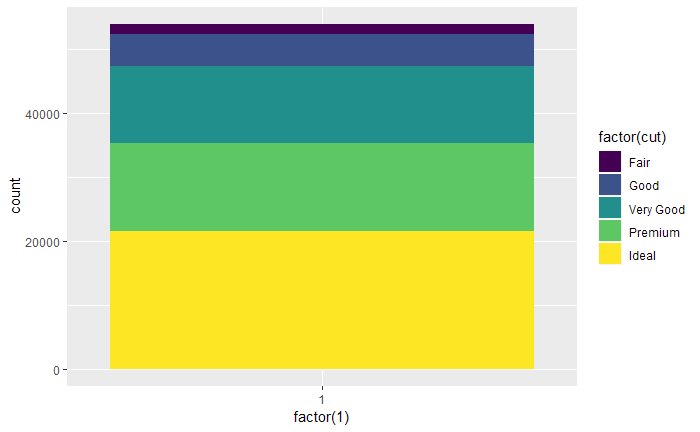

```r
bar_y <- ggplot(data = diamonds) + geom_bar(mapping = aes(x = factor(1), fill = factor(cut)), width = 1)
bar_y
```

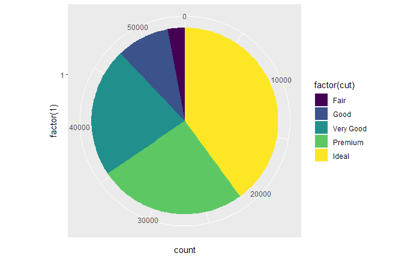

```r
bar_y + coord_polar(theta = "y")
```

- 처럼 piechart를 만들수 있다. 만약 비율로 변환하고 싶다면

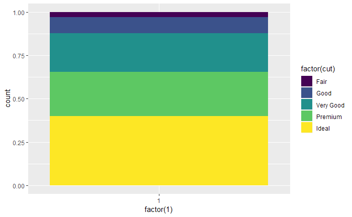

```r
bar_z <- ggplot(data = diamonds) + geom_bar(mapping = aes(x = factor(1), fill = factor(cut)), width = 1, position = "fill")
bar_z
```

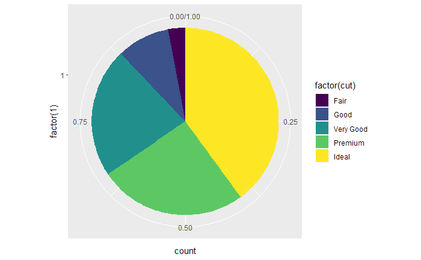

```r
bar_z + coord_polar(theta = "y")
```

- 와 같이 비율로 변환할 수 있다.
2. What does labs() do? Read the documentation.
3. What’s the difference between coord_quickmap() and coord_map()?
- 설명에 따르면 coord_map은 구면(지구를 구라고 간주하면)상의 일부분을 2차원 평면상에 사상(project)한다. 이 경우 지도의 사상(map projection)은 직선을 그대로 옮기지 않기 때문에 많은 계산이 필요하지만, 넓은 지도도 오차 없이 옮길수 있다는 점에서 장점이 있다. `coord_qucikmap()`긔 경우는 직선을 그대로 옮기기 때문에 계산의 정도는 줄어들지만, 오차가 커져 적도부근의 작은 부분지역을 옮길때 효과적이라 할 수 있다

-아래의 예시를 참조하자.

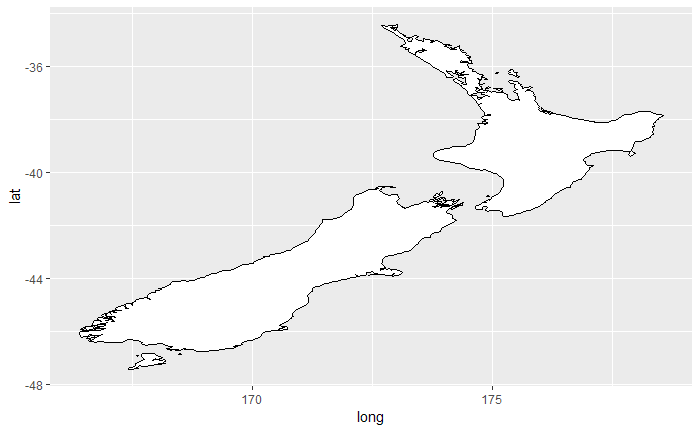

```r
library(mapproj)
nz <- map_data("nz")
# Prepare a map of NZ
nzmap <- ggplot(nz, aes(x = long, y = lat, group = group)) +
  geom_polygon(fill = "white", colour = "black")
# Plot it in cartesian coordinates
nzmap
```

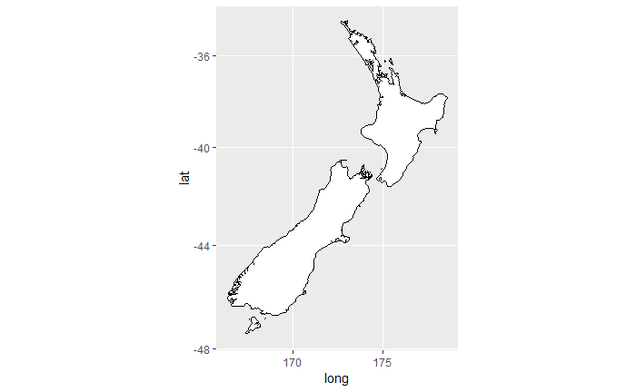

```r
# With correct mercator projection
nzmap + coord_map()
```

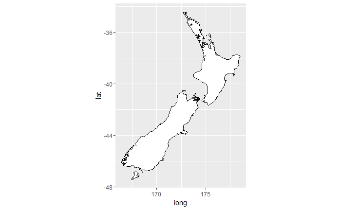

```r
# With the aspect ratio approximation
nzmap + coord_quickmap()
```

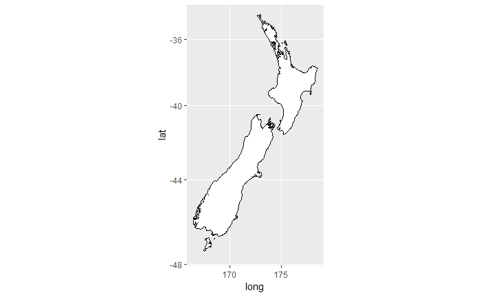

```r
nzmap + coord_map("cylindrical")
```

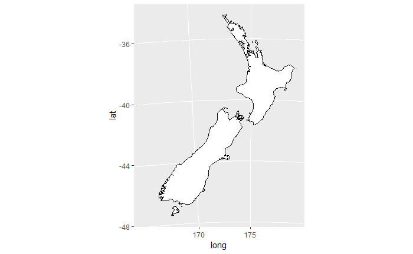

```r
nzmap + coord_map("azequalarea", orientation = c(-36.92, 174.6, 0))
```

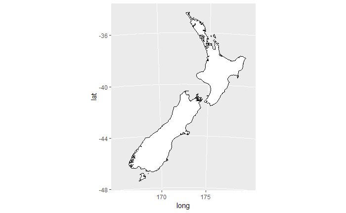

```r
nzmap + coord_map("lambert", parameters = c(-37, -44))
```

- 이제 차이가 좀 나도록 미국 지도를 그려보자.

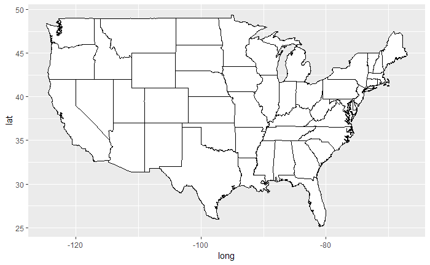

```r
states <- map_data("state")
usamap <- ggplot(states, aes(long, lat, group = group)) +
  geom_polygon(fill = "white", colour = "black")
# Use cartesian coordinates
usamap
```

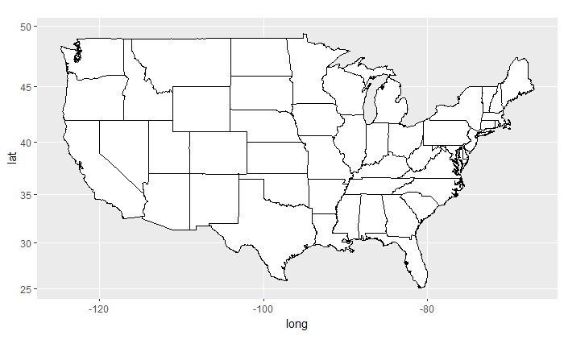

```r
# With mercator projection
usamap + coord_map()
```

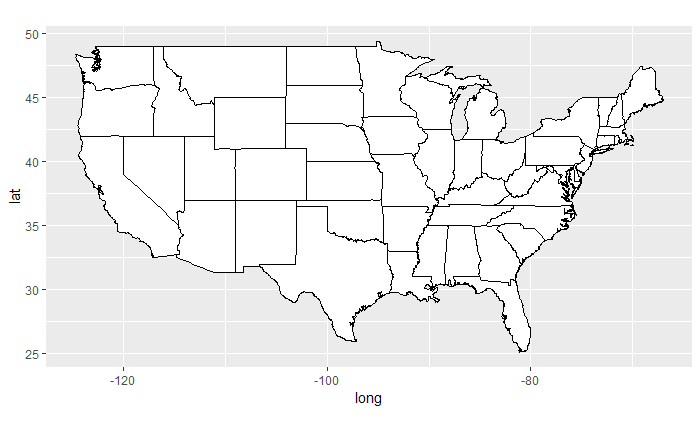

```r
usamap + coord_quickmap()
```

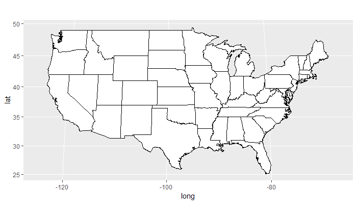

```r
usamap + coord_map("gilbert")
```

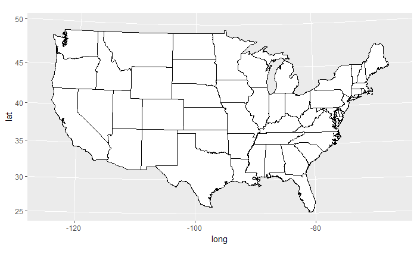

```r
usamap + coord_map("lagrange")
```

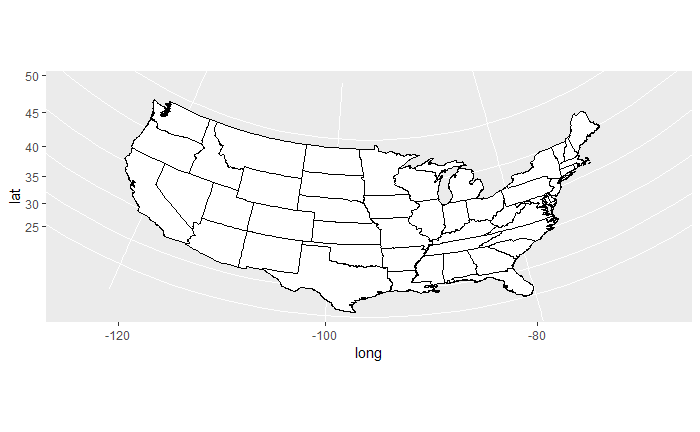

```r
usamap + coord_map("orthographic")
```

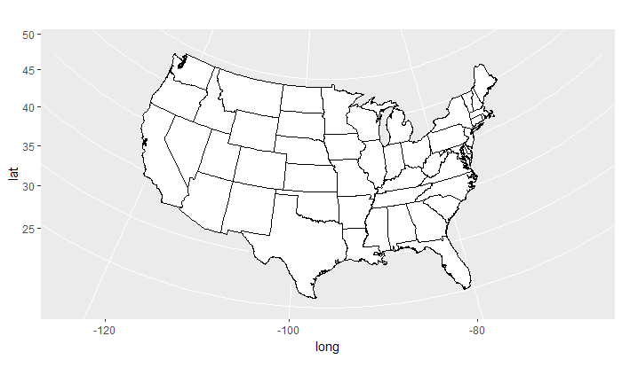

```r
usamap + coord_map("stereographic")
```

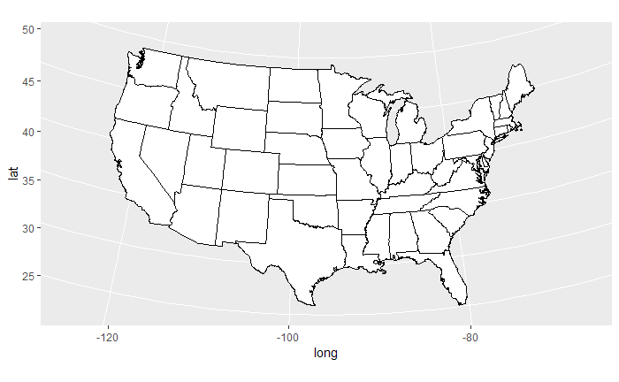

```r
usamap + coord_map("conic", lat0 = 30)
```

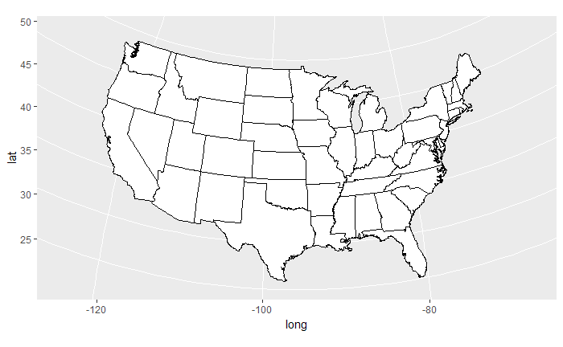

```r
usamap + coord_map("bonne", lat0 = 50)
```

4. What does the plot below tell you about the relationship between city and highway mpg? Why is coord_fixed() important? What does geom_abline() do? `ggplot(data = mpg, mapping = aes(x = cty, y = hwy)) + geom_point() + geom_abline() +coord_fixed()`
- 위 plot은 city와 highway mpg 사이에 양의 상관관계를 보여준다. 여기서 `coord_fixed()` 가 중요한 이유는 이것이 없는 상태로 그래프를 그리게 되면 x축과 y축의 눈금의 크기가 달라져 상관관계의 정도를 왜곡시켜 보여줄 가능성이 있기 때문이다. 해당 조건을 포함 시키지 않고 그런 경우 다음과 같은 그래프가 그려지는데, 아래와 같은 경우 두 축의 눈금 한칸의 길이가 같은데, x축은 눈금 한칸이 2.5인데 비해, y축은 눈금 한칸이 5를 의미하게 되어, 마치 smooth line의 slope가 1보다 작은 것처럼 보인다.

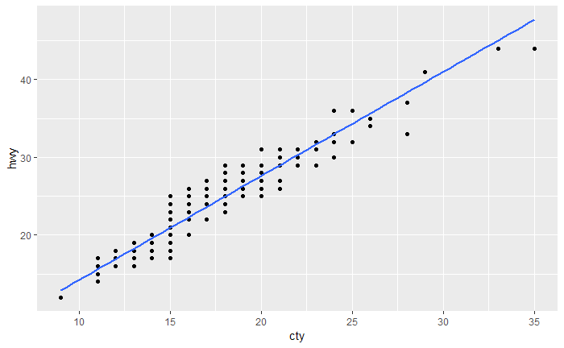

- 이제 `coord_fixed()`를 추가시켜서 그래프를 그려보자. 특히 `ratio` argument가 중요한데, 이는 x축 눈금과 y축 눈금이 비율을 설정하는 것이기 때문이다. default 값은 1로 주어져 있으므로 그대로 사용하면

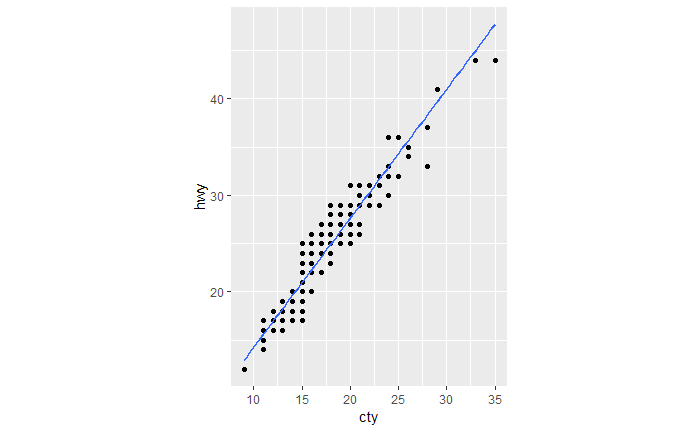

```r
ggplot(data = mpg, mapping = aes(x = cty, y = hwy)) + geom_point() + geom_smooth(method = "lm", se = FALSE) + coord_fixed()
```

- 위와 같은 그래프를 그릴 수 있는데, 처음 그래프와 마찬가지로 x축의 눈금 한칸은 2.5, y축의 눈금 한칸은 5이지만, 각 눈금의 길이 역시 그에 맞게 조정이 된 것을 확인할 수 있고, smooth line도 처음 그래프에 비해서 slope가 커진것 처럼 보이는 것을 확인할 수 있다.
- `geom_abline`은 그래프 의에 임의의 선을 그을 수 있는 함수로, slope와 intercept를 설정하여 그릴 수 있다. 아래에서 확인 할 수 있듯, default 값은 intercept = 0, slop = 1이다.

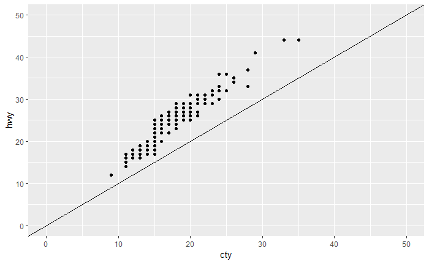

```r
ggplot(data = mpg, mapping = aes(x = cty, y = hwy)) + geom_point() + geom_abline() + coord_cartesian(xlim = c(0,50), ylim = c(0, 50))
```